# LIS 4317 Final Project

Patricia McGee

2022-04-26

## The Assignment

### The Project outline

Each student in the class will create his/her visual project. The student will share the link on Canvas. The grade for the final project will be scored based on your instructor and your classmates peer review comments and grades.

### Objectives

The purpose of this project is to apply what you’ve learned in this class: design and statistical analysis apparatus. Your project needs to capture any type of data based on your interest and utilize plot.ly, Tableau or Rstudio. The software you picked has to be covered in class in order to tell a story of your data analysis you selected. You can employ any of the techniques and practices we outline in the class. From Time series analysis, part to whole, ranking, deviation analysis, distribution, correlation, multivariate, and even promising trends as discussed in Chapter 13 in our textbook.

#### Step 1.

Begin searching for a dateset that captivates your interest. Your dataset should contain at least 50 observations and 5 to 20 variables.

#### Step 2.

You will provide a written documentation of your project objectives and accomplishments that will include a general research question and objectives. Those questions will contain your underlying theme of your project as outline below.

Short summary:

Problem description: Give a brief but precise description or definition of the problem or hypothesis you set to evaluate. Related work: How does this problem and the method relate to the problems/methods have addressed in the Provide example of existing visual analytics that you liked. Solution: How did you solve the problem? Describe the technical approach. Tell us what methodology you will take: Time series analysis, part to whole, ranking, deviation analysis, distribution, correlation, multivariate, and even promising trends.

#### Step 3.

Create a visualization of your data and discussion to your output. You can use any of the apps we covered in the class including: plot.ly, Tableau, RStudio and Python.

## My Information and Code

I have decided to use the Beer Profile and Ratings Dataset from Kaggle: https://www.kaggle.com/ruthgn/beer-profile-and-ratings-data-set

I will read in the csv file “beer_profile_and_ratings.csv” and save this as beers.

```r
beers <- read.csv("beer_profile_and_ratings.csv")
head(beers)
```

```
##                         ï..Name   Style
## 1                         Amber Altbier
## 2                    Double Bag Altbier
## 3                Long Trail Ale Altbier
## 4                  Doppelsticke Altbier
## 5 Sleigh'r Dark DoÃ¼ble Alt Ale Altbier
## 6                        Sticke Altbier
##                                             Brewery
## 1                               Alaskan Brewing Co.
## 2                            Long Trail Brewing Co.
## 3                            Long Trail Brewing Co.
## 4 Uerige ObergÃ¤rige Hausbrauerei GmbH / Zum Uerige
## 5                           Ninkasi Brewing Company
## 6 Uerige ObergÃ¤rige Hausbrauerei GmbH / Zum Uerige
##                                                        Beer.Name..Full.
```

[output cut: 34 more lines]

```r
summary(beers)
```

```
##    ï..Name             Style             Brewery          Beer.Name..Full.
##  Length:3197        Length:3197        Length:3197        Length:3197
##  Class :character   Class :character   Class :character   Class :character
##  Mode  :character   Mode  :character   Mode  :character   Mode  :character
##
##
##
##  Description             ABV            Min.IBU         Max.IBU
##  Length:3197        Min.   : 0.000   Min.   : 0.00   Min.   :  0.00
##  Class :character   1st Qu.: 5.000   1st Qu.:15.00   1st Qu.: 25.00
##  Mode  :character   Median : 6.000   Median :20.00   Median : 35.00
##                     Mean   : 6.527   Mean   :21.18   Mean   : 38.99
##                     3rd Qu.: 7.600   3rd Qu.:25.00   3rd Qu.: 45.00
##                     Max.   :57.500   Max.   :65.00   Max.   :100.00
##   Astringency         Body           Alcohol           Bitter
##  Min.   : 0.00   Min.   :  0.00   Min.   :  0.00   Min.   :  0.00
##  1st Qu.: 9.00   1st Qu.: 29.00   1st Qu.:  6.00   1st Qu.: 17.00
##  Median :14.00   Median : 40.00   Median : 11.00   Median : 31.00
##  Mean   :16.52   Mean   : 46.13   Mean   : 17.06   Mean   : 36.36
##  3rd Qu.:21.00   3rd Qu.: 58.00   3rd Qu.: 22.00   3rd Qu.: 52.00
##  Max.   :81.00   Max.   :175.00   Max.   :139.00   Max.   :150.00
##      Sweet             Sour            Salty            Fruits
##  Min.   :  0.00   Min.   :  0.00   Min.   : 0.000   Min.   :  0.00
##  1st Qu.: 33.00   1st Qu.: 11.00   1st Qu.: 0.000   1st Qu.: 12.00
##  Median : 54.00   Median : 22.00   Median : 0.000   Median : 29.00
##  Mean   : 58.27   Mean   : 33.15   Mean   : 1.017   Mean   : 38.53
##  3rd Qu.: 77.00   3rd Qu.: 42.00   3rd Qu.: 1.000   3rd Qu.: 60.00
##  Max.   :263.00   Max.   :284.00   Max.   :48.000   Max.   :175.00
##      Hoppy            Spices           Malty         review_aroma
##  Min.   :  0.00   Min.   :  0.00   Min.   :  0.00   Min.   :1.510
##  1st Qu.: 18.00   1st Qu.:  4.00   1st Qu.: 45.00   1st Qu.:3.423
##  Median : 33.00   Median : 10.00   Median : 73.00   Median :3.720
##  Mean   : 40.92   Mean   : 18.35   Mean   : 75.33   Mean   :3.639
##  3rd Qu.: 56.00   3rd Qu.: 23.00   3rd Qu.:103.00   3rd Qu.:3.978
##  Max.   :172.00   Max.   :184.00   Max.   :239.00   Max.   :5.000
##  review_appearance review_palate    review_taste   review_overall
##  Min.   :1.571     Min.   :1.286   Min.   :1.214   Min.   :1.136
##  1st Qu.:3.605     1st Qu.:3.470   1st Qu.:3.500   1st Qu.:3.567
##  Median :3.833     Median :3.742   Median :3.792   Median :3.830
##  Mean   :3.754     Mean   :3.660   Mean   :3.702   Mean   :3.748
##  3rd Qu.:4.000     3rd Qu.:3.966   3rd Qu.:4.033   3rd Qu.:4.033
##  Max.   :4.667     Max.   :5.000   Max.   :5.000   Max.   :5.000
##  number_of_reviews
##  Min.   :   1.0
##  1st Qu.:  23.0
##  Median :  93.0
##  Mean   : 233.3
##  3rd Qu.: 284.0
##  Max.   :3290.0
```

## Exploring and Cleaning the Data

First, we need to narrow this dataset down for our purposes. There are currently 3197 observations.

We remove some fields that we don’t need. We will remove Description and the Min.IBU and Max.IBU.

Then we will filter this to only select Styles. I have chosen 8 beer styles that I enjoy. They are: Blonde Ale - Belgian Cream Ale Lager - American Pumpkin Beer Red Ale - Irish Stout - Irish Dry Stout - Sweet / Milk Wheat Beer - Hefeweizen

This brings us down to 248 observations.

```r
library(dplyr)
```

```r
beers <- beers[,-7:-8]
beers <- beers[,-5]

beers <- beers %>%
  rename(Name = ï..Name, FullBeerName = Beer.Name..Full.)

beers_filtered <- beers %>%
  filter(Style %in% c("Blonde Ale - Belgian","Cream Ale","Lager - American",
                      "Pumpkin Beer","Red Ale - Irish","Stout - Irish Dry",
                      "Stout - Sweet / Milk","Wheat Beer - Hefeweizen"))

top_beers <- beers_filtered %>%
  arrange(desc(review_overall))%>%
  top_n(n = 10, review_overall)

topABVbeers <- beers_filtered %>%
  arrange(desc(ABV))%>%
  top_n(n = 10, ABV)
```

## Plots

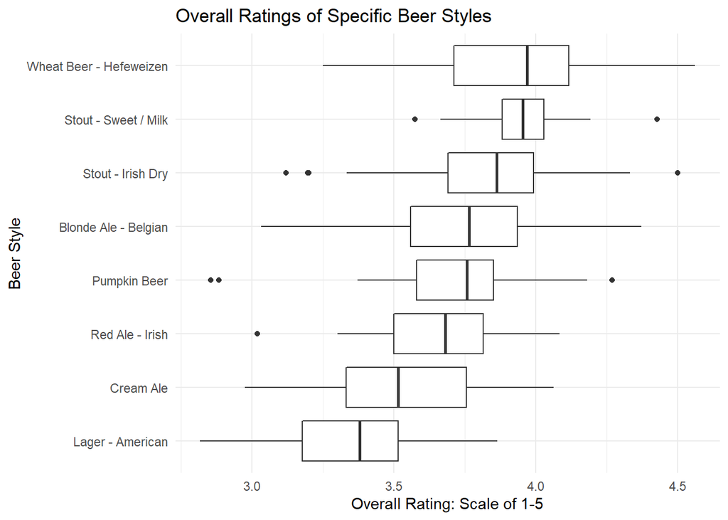

```r
library(ggplot2)
library(stringr)
library(forcats)

beers_filtered %>%
  mutate(BeerStyle = fct_reorder(Style, review_overall))%>%
  ggplot(aes(BeerStyle, review_overall))+
  geom_boxplot()+
  coord_flip()+
  theme_minimal()+
  labs(title = "Overall Ratings of Specific Beer Styles", x = "Beer Style",
       y = "Overall Rating: Scale of 1-5")
```

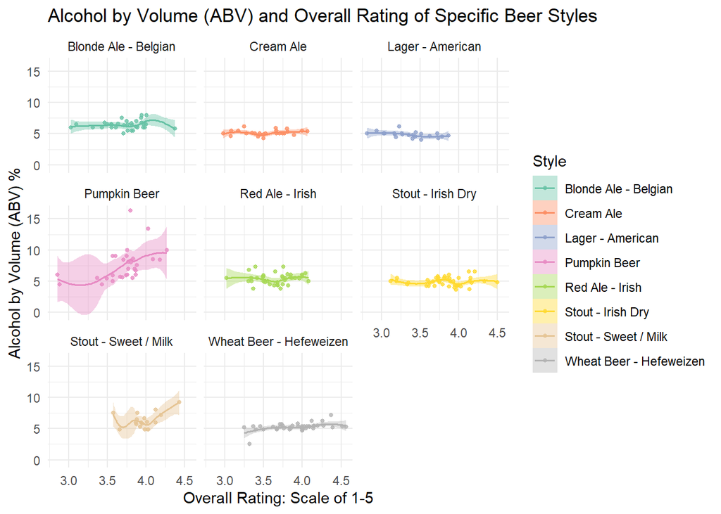

```r
ggplot(beers_filtered, aes(review_overall, ABV))+
  geom_point(size = 1, alpha = 0.8, aes(color = Style))+
  geom_smooth(size = 0.6, aes(color = Style, fill = Style))+
  theme_minimal()+
  scale_color_brewer(palette = "Set2")+
  scale_fill_brewer(palette = "Set2")+
  facet_wrap(vars(Style))+
  labs(title = "Alcohol by Volume (ABV) and Overall Rating of Specific Beer Styles",
       x = "Overall Rating: Scale of 1-5", y = "Alcohol by Volume (ABV) %")
```

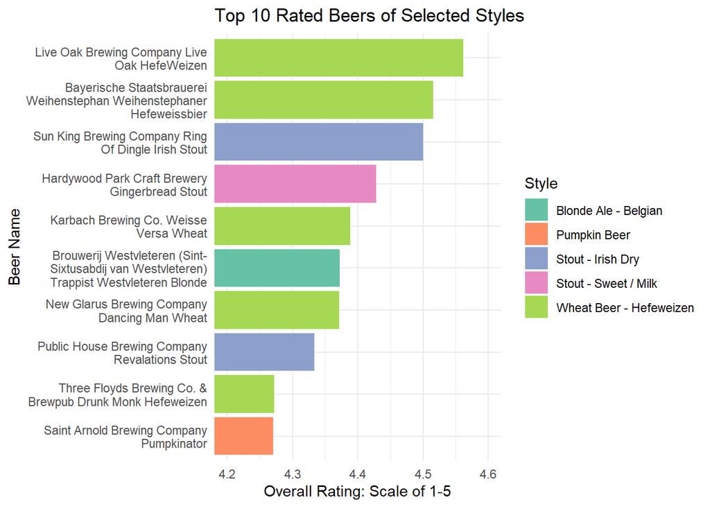

```r
top_beers %>%
  mutate(Beer = fct_reorder(FullBeerName,review_overall)) %>%
  ggplot(aes(review_overall, Beer))+
  geom_col(aes(fill = Style))+
  coord_cartesian(xlim = c(4.2,4.6))+
  scale_fill_brewer(palette = "Set2")+
  scale_y_discrete(labels = function(y) str_wrap(y, width = 30))+
  labs(title = "Top 10 Rated Beers of Selected Styles", y = "Beer Name",
       x = "Overall Rating: Scale of 1-5")+
  theme_minimal()
```

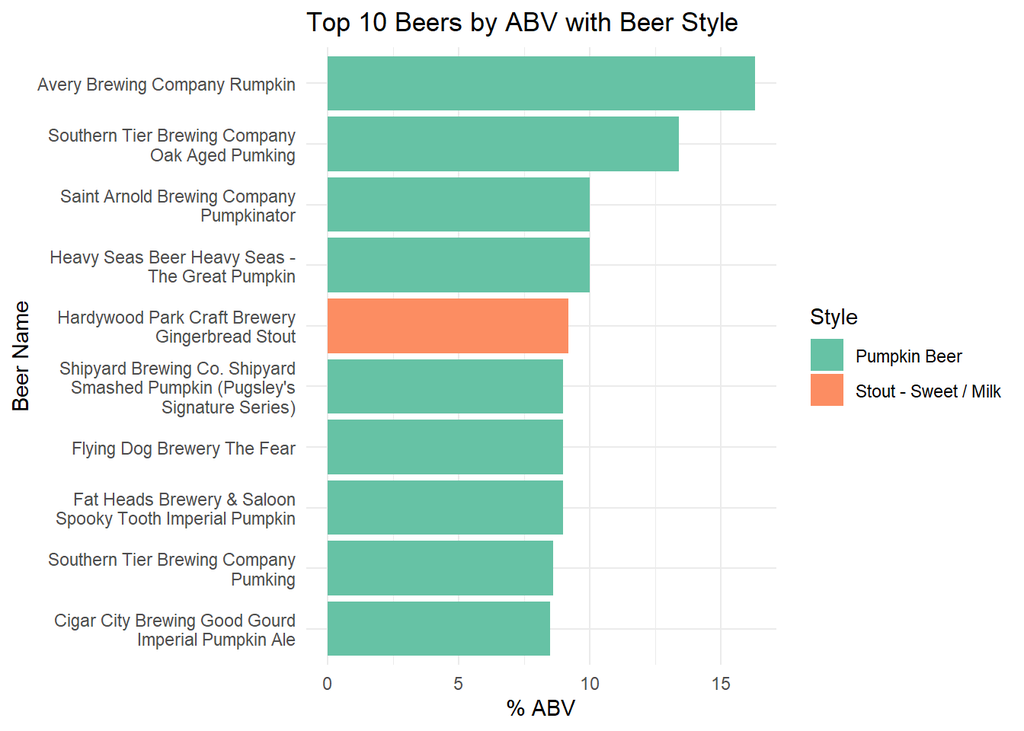

```r
topABVbeers %>%
  mutate(Beer = fct_reorder(FullBeerName,ABV))%>%
  ggplot(aes(Beer, ABV))+
  geom_col(aes(fill = Style))+
  coord_flip()+
  scale_fill_brewer(palette = "Set2")+
  scale_x_discrete(labels = function(x) str_wrap(x, width = 30))+
  labs(title = "Top 10 Beers by ABV with Beer Style", x = "Beer Name", y = "% ABV")+
  theme_minimal()
```